# Using continuous integration services when developing Bioconductor packages

8 September 2015

## What this talk is

- Part instructional
- Part wishlist and work-in-progress

## The whats and whys of CI

## The what

[figure not shown]

http://stackoverflow.com/q/463511

## 8000 (excellent, general, somewhat dated) words of explanation

http://martinfowler.com/articles/continuousIntegration.html

## What is CI for R/BioC packages?

Regular and automated running of `R CMD build` and `R CMD check` when you make changes to your R package

## The why

- Because I don't run `R CMD build` and `R CMD check` as often as I should
- Because if I do then I only run them on **my setup**
- Get automatic checking of pull requests

## How's CI different from XYZ?

## [win-builder](http://win-builder.r-project.org/)

- **Be nice :)**
- One machine, provided and maintained in donated time by Uwe Ligges (R-core & CRAN maintainer for Windows)
- "Please do not upload Bioconductor packages or CRAN packages"
- No (immediate) GitHub integration
  - But might using `devtools::build_win()`
- See first point

## [Bioconductor multiple platform build/check report](http://bioconductor.org/checkResults/devel/bioc-LATEST/)

- **Package must be already part of Bioconductor**
- Software packages built daily
- Release branch
  - Linux (Ubuntu 14.04.2 LTS)
  - Windows Server 2008 R2 Enterprise SP1 (64-bit)
  - Mac OS X Snow Leopard (10.6.8)
  - Mac OS X Mavericks (10.9.5)
- Devel branch
  - Linux (Ubuntu 14.04.2 LTS)
  - Windows Server 2012 R2 Enterprise SP1 (64-bit)
  - Mac OS X Snow Leopard (10.6.8)

## What follows assumes you use GitHub

## Don't worry, options exist if you don't

## Version control

### Options

- https://github.com/
- https://bitbucket.org/
- https://about.gitlab.com/
- Several others [e.g., for non-Git-based respositories]

> "… I think Git + GitHub is the most user-friendly system (especially for new developers), not least because its popularity means that the answer or solution to every possible question or problem can be found on StackOverflow" [[Hadley Wickham](http://r-pkgs.had.co.nz/git.html)]

## Continuous Integration

### Options

- https://travis-ci.org/
- https://jenkins-ci.org/
- https://codeship.com/
- https://circleci.com/
- https://semaphoreci.com/
- https://drone.io/
- http://www.appveyor.com/
- http://wercker.com/
- https://en.wikipedia.org/wiki/Comparison_of_continuous_integration_software

### Considerations

- Native R support
- Operating system support
- Code coverage support (via https://github.com/jimhester/covr)

## Travis

## Travis

### Pros

- Only CI that has native R support
  - But still incomplete …
- Supports both Linux and OS X
- Biggest R community
- Simple integration with code coverage services [Codecov](https://codecov.io/) and [Coveralls](https://coveralls.io/) via https://github.com/jimhester/covr

### Cons

- No Windows support but that is provided by http://www.appveyor.com/, e.g. https://github.com/krlmlr/r-appveyor/

## R + CI

## R + CI Travis

## A word of warning

- R + CI are a moving target
- Even more so once you throw Bioconductor into the mix

## Basics

1. Ensure your package is on GitHub
2. Create a `.travis.yml` file in top-level of package directory
   - Can use `devtools::use_travis()`
3. Go to https://travis-ci.org and flick the switch on the repo you want to test

## Basics

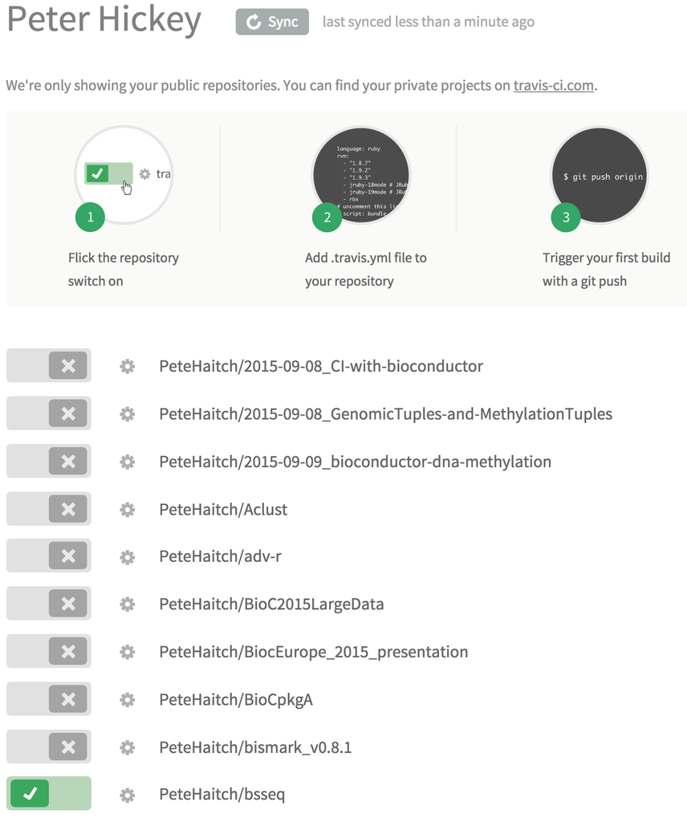

## Basics

1. Ensure your package is on GitHub
2. Create a `.travis.yml` file in top-level of package directory
   - Can use `devtools::use_travis()`
3. Go to https://travis-ci.org and flick the switch on the repo you want to test
4. Commit and push to GitHub.
5. Wait a few minutes for email notification of result (or follow the action [live](https://travis-ci.org/PeteHaitch/GenomicTuples) at https://travis-ci.org)

## `.travis.yml`

## Minimalist

```yaml
language: r
sudo: required # See docs for details
```

Will install (from source) all CRAN-based dependencies listed in `DESCRIPTION` (except those in `SUGGESTS`)

## `devtools::use_travis()`

Adds some useful options:

```yaml
# Sample .travis.yml for R projects

language: r
warnings_are_errors: true
sudo: required

env:
 global:
   - CRAN: http://cran.rstudio.com

notifications:
  email:
    on_success: change
    on_failure: change
```

## Other useful (documented) options

```yaml
# Other useful things to stick in .travis.yml
bioc_packages: GenomicRanges # Use **release** branch of BioC
r_github_packages: hadley/dplyr # user/repo
r_binary_packages: testthat # faster (binary rather than source)
r_check_args: "--no-vignettes --timings" # mimic the BioC build machines
```

Read http://docs.travis-ci.com/ and http://docs.travis-ci.com/user/languages/r/

[figure not shown]

## A useful (undocumented) option

See https://github.com/travis-ci/travis-build/blob/master/lib/travis/build/script/r.rb

[figure not shown]

```yaml
# Yay, you can use the devel branch of Bioconductor
bioc_use_devel: true


# But ...
```

## Still can't (easily or at all)

- Test on multiple versions of R
- Run more complicated pre- or post-installation commands
- Test on different versions of a dependency
  - E.g., [*dplyr*'s use of Rcpp-release and Rcpp-devel](https://github.com/hadley/dplyr/blob/master/.travis.yml)

## r-builder

## More power, more effort

### https://github.com/metacran/r-builder

#### Pros

- Even more flexibility
- Uses devel branch of Bioconductor by default :)
- Allows multiple versions of R per build
- Also supports other CIs

#### Cons

- Does not currently support OS X on Travis
- Bit more effort (but not much when dealing with a mildly complicated package)

## A basic BioC-devel `.travis.yml` for use with *r-builder*

```yaml
language: c
sudo: required
before_install:
  - curl -OL https://raw.githubusercontent.com/metacran/r-builder/master/pkg-build.sh
  - chmod 755 pkg-build.sh
  - ./pkg-build.sh bootstrap
install:
  - ./pkg-build.sh install_bioc_deps
script:
  - ./pkg-build.sh run_tests
after_failure:
  - ./pkg-build.sh dump_logs
notifications:
  email:
    on_success: change
    on_failure: change
env:
  global:
    - BOOTSTRAP_LATEX=true # Required to build pdf vignettes (+ manual); slower
    - R_CHECK_ARGS="--no-vignettes --timings" # Mimic BioC build machines
  matrix:
    - RVERSION=3.2.2 # BioC 3.2 uses R 3.2.x. Needs to be manually updated upon new BioC version
```

## On the horizon

## Things I want (ought to do)

- Yes, I'm volunteering to help
- Simplified `.travis.yml` for bioc-devel and bioc-release
- Multiple R versions with Travis's native R support
- Using official BioC Docker containers to replicate(?) BioC build machines
- `R CMD BiocCheck`
- A guide on https://bioconductor.org/

## Summary

## Wrapping up

- CI saves you time
- Basic and simple support for R/Bioconductor with [Travis](http://docs.travis-ci.com/user/languages/r/)
- Advanced and more complex support for R/Bioconductor with [*r-builder*](https://github.com/metacran/r-builder)
- Non-Travis, non-mac/linux options are availabe but require extra work

## What other tricks you got, boy?

### Other uses for CI + R ( from http://r-pkgs.had.co.nz/check.html#travis)

- Re-publishing a book website every time you make a change to the source (like http://r-pkgs.had.co.nz/)
- Building vignettes and publishing them to a website
- Automatically building a documentation website for your package

### https://github.com/jimhester/covr

- Automatically run tests, find out where you do well and where to improve

## Further reading

### Git + GitHub

- **Thorough**: http://r-pkgs.had.co.nz/git.html

### Travis

- **Basic**: http://r-pkgs.had.co.nz/check.html#travis
- **Official**: http://docs.travis-ci.com/user/languages/r/
- **Official (but undocumented)**: https://github.com/travis-ci/travis-build/blob/master/lib/travis/build/script/r.rb
- **Advanced**: https://github.com/metacran/r-builder

### *covr*

- **Horse's mouth**: https://github.com/jimhester/covr

### These slides

- bit.ly/BioC-CI (or visit my GitHub page, https://github.com/PeteHaitch/)